# Simulating Datasets

# Load or install packages for this lesson

```r
# Load packages

ipak <- function(pkg){
  new.pkg <- pkg[!(pkg %in% installed.packages()[, "Package"])]
  if (length(new.pkg))
    install.packages(new.pkg, dependencies = TRUE)
  sapply(pkg, require, character.only = TRUE)
}

# usage
packages <- c("ggplot2", "Rmisc", "tidyr", "Hmisc", "psych")
ipak(packages)
```

```
## ggplot2   Rmisc   tidyr   Hmisc   psych
##    TRUE    TRUE    TRUE   FALSE    TRUE
```

# Simulating datasets

There are many ways to simulate factorial datasets. We will use a step-by-step approach to make sure that you are getting familiar with every aspect of datasets based on factorial design.

## The concept behind creating a single level of a dataset.

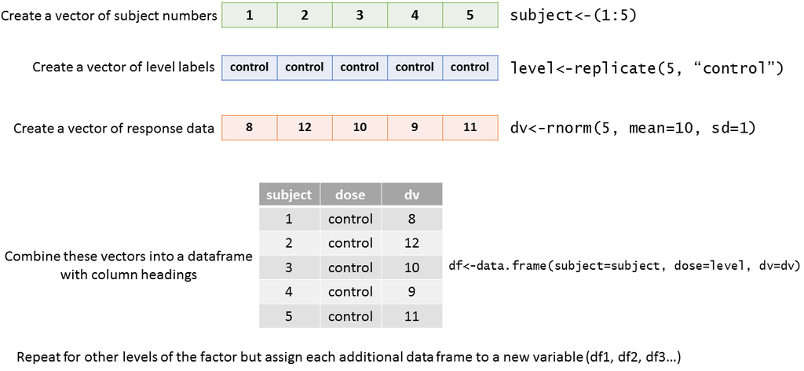

## Combining multiple data frames representing each levels of a factor into a single dataset.

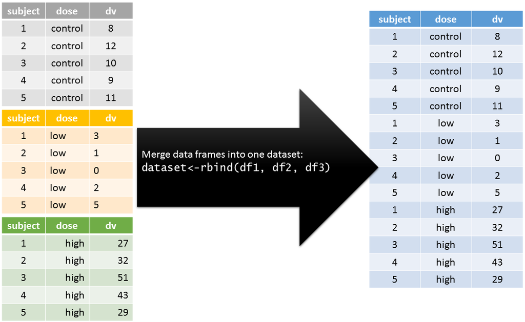

Below I am simulating a dataset with a factor “dose” which has 4 levels (control, low, medium, and high) and response (dependent) variable “dv”.

Step 1: create data for the first level of your factor Attention: everything after a # is a comment and is not a part of a code required to construct a dataset.

```r
subject<-(1:10) # create a vector with subject numbers
subject # verify vector
```

```
##  [1]  1  2  3  4  5  6  7  8  9 10
```

```r
level<-replicate(10, "control") # create a vector of level labels
level # verify vector
```

```
##  [1] "control" "control" "control" "control" "control" "control" "control"
##  [8] "control" "control" "control"
```

```r
# create a vector with response variable
dv<-rnorm(10, mean=10, sd=1)
# here you can set desired number of subjects, mean, and sd for that level.
dv # verify vector
```

```
##  [1]  9.589641  8.256174  9.125954  9.993521  9.962703  8.871645 12.444429
##  [8]  8.685667 10.824108 11.255484
```

```r
#combine vectors (subject, level, dv) into a dataframe
df1<-data.frame(subject=subject, dose=level, dv=dv)
df1 # verify data frame
```

```
##    subject    dose        dv
## 1        1 control  9.589641
## 2        2 control  8.256174
## 3        3 control  9.125954
## 4        4 control  9.993521
## 5        5 control  9.962703
## 6        6 control  8.871645
## 7        7 control 12.444429
## 8        8 control  8.685667
## 9        9 control 10.824108
## 10      10 control 11.255484
```

Step 2: Repeat process with modifications to create data for the second level of your factor}

```r
subject<-(1:10)
subject
```

```
##  [1]  1  2  3  4  5  6  7  8  9 10
```

```r
level<-replicate(10, "low") # change to another level
level
```

```
##  [1] "low" "low" "low" "low" "low" "low" "low" "low" "low" "low"
```

```r
dv<-rnorm(10, mean=23, sd=3)
# change to reflect the effect (higher or lower responding; more or less variance).
# Here you are in control of your effects. Think how you want to play this out.
dv
```

```
##  [1] 20.16562 24.83050 16.08176 20.73639 22.46845 21.62846 21.78828 22.08087
##  [9] 20.00266 20.34744
```

```r
df2<-data.frame(subject=subject, dose=level, dv=dv) # combine to another df
df2
```

```
##    subject dose       dv
## 1        1  low 20.16562
## 2        2  low 24.83050
## 3        3  low 16.08176
## 4        4  low 20.73639
## 5        5  low 22.46845
## 6        6  low 21.62846
## 7        7  low 21.78828
## 8        8  low 22.08087
## 9        9  low 20.00266
## 10      10  low 20.34744
```

Step 3: Repeat process with modifications to create data for the third level of your factor

```r
subject<-(1:10)
# change to appropriate subject number.
# Same if within subjects, different if between subjects
subject
```

```
##  [1]  1  2  3  4  5  6  7  8  9 10
```

```r
level<-replicate(10, "medium") # change to another level
level
```

```
##  [1] "medium" "medium" "medium" "medium" "medium" "medium" "medium" "medium"
##  [9] "medium" "medium"
```

```r
dv<-rnorm(10, mean=42, sd=5)
# change to reflect the effect (higher or lower responding; more or less variance).
# Here you are in control of your effects. Think how you want to play this out.
dv
```

```
##  [1] 46.12116 30.53535 40.09139 48.47589 50.66481 39.13707 45.65706 39.72509
##  [9] 36.73526 44.30967
```

```r
df3<-data.frame(subject=subject, dose=level, dv=dv) # combine to another df
df3
```

```
##    subject   dose       dv
## 1        1 medium 46.12116
## 2        2 medium 30.53535
## 3        3 medium 40.09139
## 4        4 medium 48.47589
## 5        5 medium 50.66481
## 6        6 medium 39.13707
## 7        7 medium 45.65706
## 8        8 medium 39.72509
## 9        9 medium 36.73526
## 10      10 medium 44.30967
```

```r
subject<-(1:10)
subject
```

```
##  [1]  1  2  3  4  5  6  7  8  9 10
```

```r
level<-replicate(10, "high") # change to another level
level
```

```
##  [1] "high" "high" "high" "high" "high" "high" "high" "high" "high" "high"
```

```r
dv<-rnorm(10, mean=80, sd=10)
# change to reflect the effect (higher or lower responding; more or less variance).
# Here you are in control of your effects. Think how you want to play this out.
dv
```

```
##  [1] 74.73517 89.66392 66.63674 90.44127 78.08582 70.20915 79.78285 78.48993
##  [9] 69.69300 79.88686
```

```r
df4<-data.frame(subject=subject, dose=level, dv=dv)
df4
```

```
##    subject dose       dv
## 1        1 high 74.73517
## 2        2 high 89.66392
## 3        3 high 66.63674
## 4        4 high 90.44127
## 5        5 high 78.08582
## 6        6 high 70.20915
## 7        7 high 79.78285
## 8        8 high 78.48993
## 9        9 high 69.69300
## 10      10 high 79.88686
```

Merge data frames into one dataset

```r
df<-rbind(df1, df2, df3, df4)
df # verify complete dataset
```

```
##    subject    dose        dv
## 1        1 control  9.589641
## 2        2 control  8.256174
## 3        3 control  9.125954
## 4        4 control  9.993521
## 5        5 control  9.962703
## 6        6 control  8.871645
## 7        7 control 12.444429
## 8        8 control  8.685667
## 9        9 control 10.824108
## 10      10 control 11.255484
## 11       1     low 20.165619
## 12       2     low 24.830497
## 13       3     low 16.081765
## 14       4     low 20.736385
```

[output cut: 26 more lines]

## Data summaries | Descriptive statistics

```r
# Get summary for a complete dataset
summary(df)
```

```
##     subject         dose                 dv
##  Min.   : 1.0   Length:40          Min.   : 8.256
##  1st Qu.: 3.0   Class :character   1st Qu.:15.172
##  Median : 5.5   Mode  :character   Median :27.683
##  Mean   : 5.5                      Mean   :37.705
##  3rd Qu.: 8.0                      3rd Qu.:54.658
##  Max.   :10.0                      Max.   :90.441
```

```r
# Get a bit expand look at your data

# Use psych package

describe(df) # Nice output with sds, ses, and means
```

```
##         vars  n  mean    sd median trimmed   mad  min   max range skew kurtosis
## subject    1 40  5.50  2.91   5.50    5.50  3.71 1.00 10.00  9.00  0.0    -1.31
## dose*      2 40   NaN    NA     NA     NaN    NA  Inf  -Inf  -Inf   NA       NA
## dv         3 40 37.71 26.66  27.68   35.42 26.25 8.26 90.44 82.19  0.6    -1.10
##           se
## subject 0.46
## dose*     NA
## dv      4.22
```

```r
# Use Rmisc pacakge

summarySE(df, measurevar="dv", groupvar="dose") # really good for visualizing with error bars
```

```
##      dose  N        dv       sd        se        ci
## 1 control 10  9.900933 1.295627 0.4097133 0.9268359
## 2    high 10 77.762471 7.935437 2.5094056 5.6766699
## 3     low 10 21.013042 2.245668 0.7101426 1.6064541
## 4  medium 10 42.145275 6.043066 1.9109852 4.3229489
```

## Visualizing factorial data

Attention:} everything after a # is a comment and is not a part of a code required to construct a dataset.

Attention:} the very first bracket “>”} is to show a console prompt. This very first bracket is not a part of a code. If you are writing these commands in the text editor you do not need to include them as a part of your code.

Here is the code to visualize data from the example above (df). The conceptual progression of steps used to visualize this data is presented in figure format at the end of this section.

First lets install ggplot2} package to make pretty figures.

> install.packages(“ggplot2”) # you only need to install any package once

> library(ggplot2)

### Boxplot

Let’s use “ggplot” function to visualize our data using boxplots.

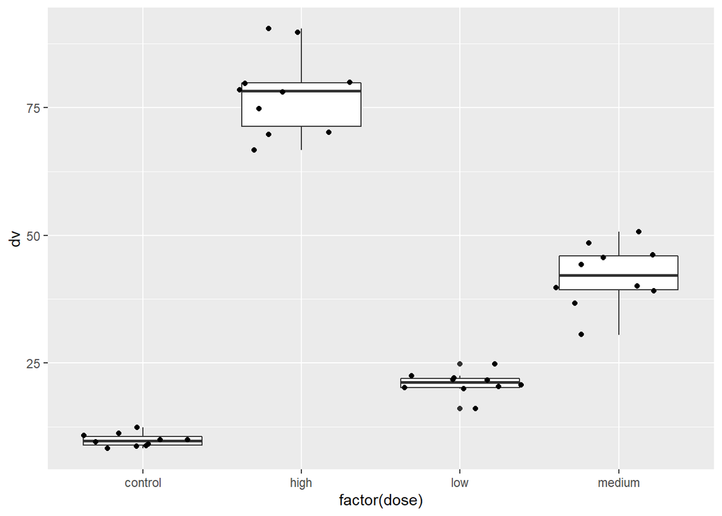

```r
library(ggplot2) # load ggplot package so we can use ggplot() function

ggplot(df, aes(factor(dose), dv)) + # creates empty plot\\
    geom_boxplot() + # to create boxplots on the plot\\
    geom_jitter() # this will visualize every data point on the plot
```

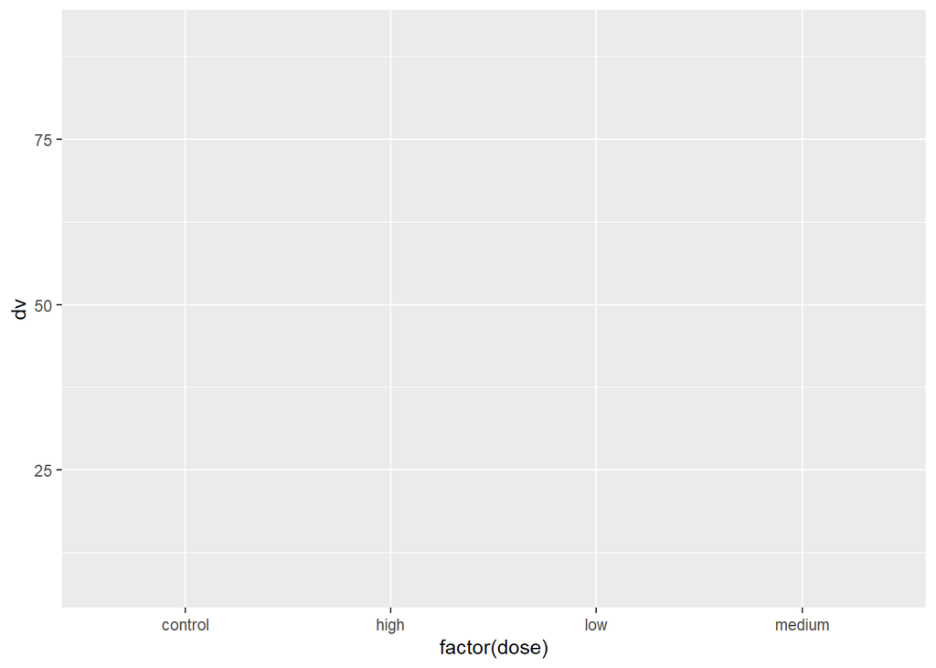

```r
# Lets brake it down line by line

p1<-ggplot(df, aes(factor(dose), dv)) # create an empty plot from df dataset, with these x and y variables. Let ggplot know that dose is a factor.
p1 # lets see our empty plot
```

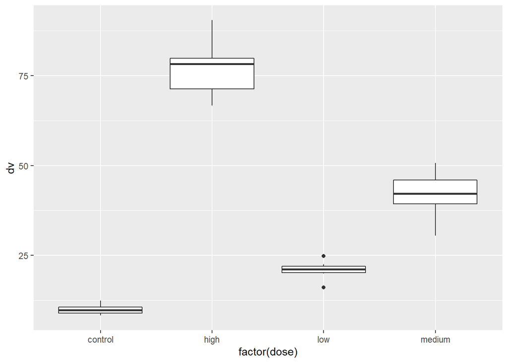

```r
p1<-p1+geom_boxplot() # lets add boxplot layer
p1 # lets visualize our creation
```

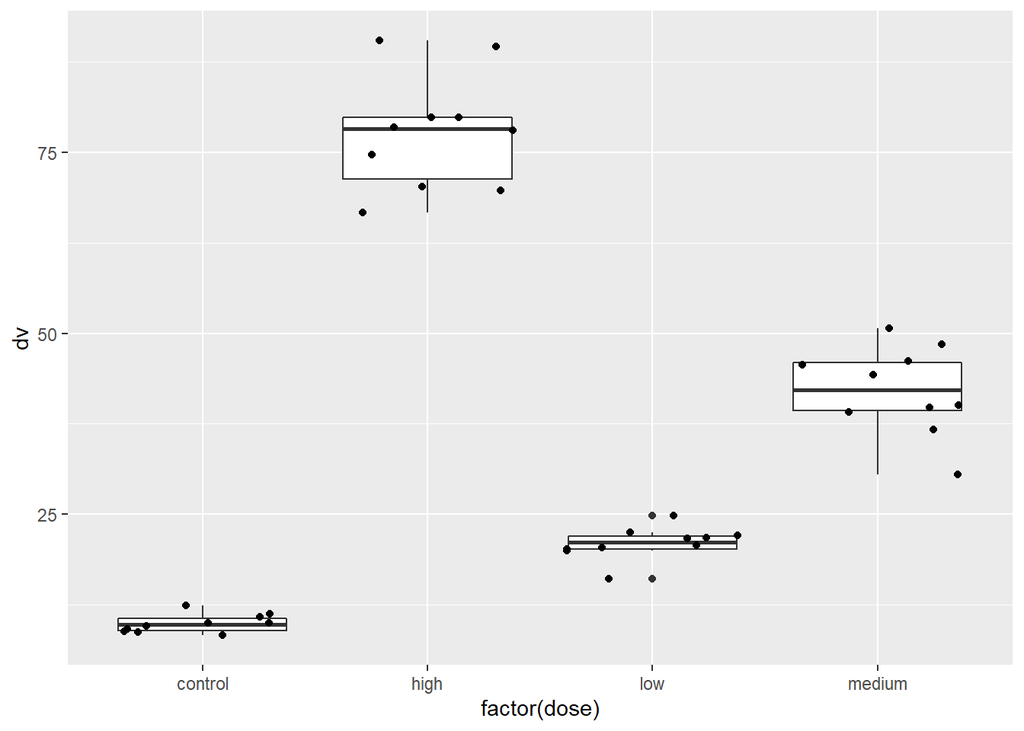

```r
p1<-p1+geom_jitter()
p1 # lets visualize our creation
```

The box plot (a.k.a. box and whisker diagram) is a standardized way of displaying the distribution of data based on the five number summary: minimum, first quartile, median, third quartile, and maximum.

### Line, point, and error bars

Let’s load additional package to help us with error bars.

> install.packages(“Rmisc”) # you only need to install any package once

Now let’s get standard errors for our dataset

```r
library(Rmisc) # load Rmisc package so we can use summarySE() function

dfse <- summarySE(df, measurevar="dv", groupvars=c("dose")) # get standard errors for df
dfse # let's see if we got those se (standard errors for each mean)
```

```
##      dose  N        dv       sd        se        ci
## 1 control 10  9.900933 1.295627 0.4097133 0.9268359
## 2    high 10 77.762471 7.935437 2.5094056 5.6766699
## 3     low 10 21.013042 2.245668 0.7101426 1.6064541
## 4  medium 10 42.145275 6.043066 1.9109852 4.3229489
```

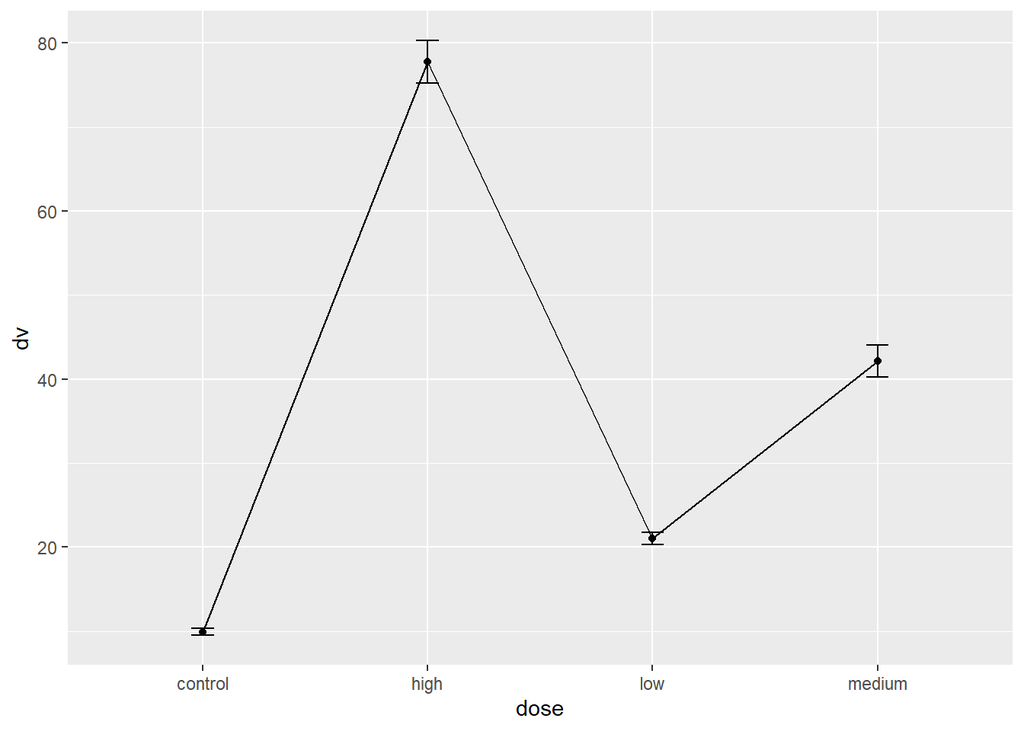

```r
# Now let's visualize our data using line, point, and error bar.

ggplot(dfse, aes(x=dose, y=dv, group=1)) +
            geom_line() +
            geom_point() +
            geom_errorbar(aes(ymin=dv-se, ymax=dv+se), width=.1)
```

### Barplot

Let’s use “ggplot” function to visualize our data using a barplot. We will use the same dataset that includes means for each condition and standard error (se) for each condition (see figures below for more details).

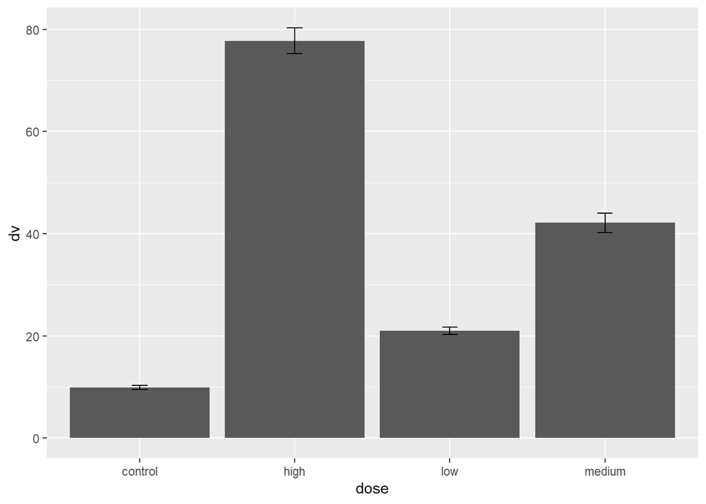

```r
library(ggplot2) # load ggplot package so we can use ggplot() function

ggplot(dfse, aes(x=dose, y=dv)) +
            geom_bar(stat="identity") +
            geom_errorbar(aes(ymin=dv-se, ymax=dv+se), width=.1)
```

### Saving figures from RStudio

1. To save figure from RStudio: find and click “Export” above the figure.
2. Choose format, destination, and/or size and save.

### Choosing figure format

What is best for my data?

- line connecting points often used for within subjects designs
- boxplots and barplots are often used for between subject designs

### Visualizing dataset using ggplot package.

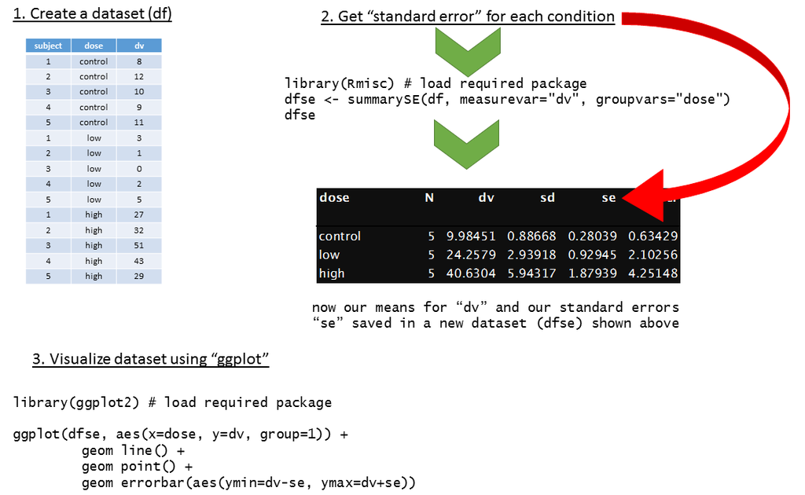

### The anatomy of a “ggplot” function

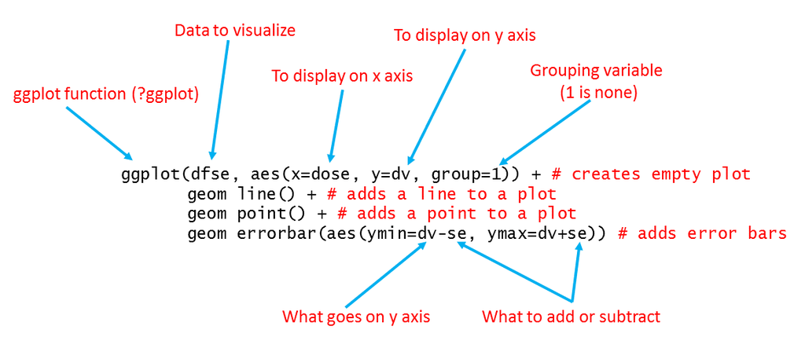

# Additional learning opportunities

1. Simulating data 1
- create a vector of random 100 numbers with custom mean and sd parameters
- assign this vector to a variable (one letter or multiple letters such as a word)
- plot these values
- get a histogram of these values
2. Simulating data 2
- create a vector of random 100 numbers
- create a histogram of this vector
- find SD of this vector
- find a mean of this vector
3. Simulating data 3
- create a data frame with three columns
- create a summary of this data frame
- get sd for each column
- get mean for each column
4. Simulating factorial design dataset. Please simulate a dataset from the following hypothetical experiment:

In this experiment human subjects come to the race track. At the race track participants are asked to complete an obstacle course task driving a mid-size sedan car. 30 min prior to the driving task, participants drink 0, 1, 3, or 5 standard alcohol drinks. Each participants comes to the track once a week on the weekend until they experience all 4 alcohol conditions. At the end of the driving task experimenter logs a number of traffic cones, that used to outline each obstacle, knocked down by each driver. There were total 12 subjects that participated in this experiment.

- Please simulate the dataset as you think it should reflect the results of this experiment.
- Please make sure that variance in each condition is different from other conditions.
- Please visualize the results of this experience as you see fit.
5. Simulating factorial design dataset. Please simulate a dataset from the following hypothetical experiment:

In this experiment four groups of participants are given experimental drug that was designed to enhance performance of troops facing sleep deprivation conditions. In this experiment all subjects are first sleep deprived for 36 hours and then are asked to complete an obstacle course task driving a mid-size sedan car. 1 hour prior to the driving task participants are given 0, 10, 50, or 200 mg of this experimental drug and then asked to drive through the obstacle course. At the end of the driving task experimenter logs a number of traffic cones, that used to outline each obstacle, knocked down by each driver. There were 32 total participants (8 subjects per group).

- Please simulate the dataset as you think it should reflect the results of this experiment.
- Please make sure that variance in each condition is different from other conditions.
- Please visualize the results of this experience as you see fit.
6. Simulating data typical for your line of research.
- Please simulate a typical dataset used in your line of research.
- Please visualize your dataset as you see fit.
- Please narrate the effects as you would expect them to occur in real experiment.